# Import Libraries

```python
import pandas as pd
import seaborn as sns
import numpy as np
import random
import os
import datetime

from autogluon.tabular import TabularPredictor

from sklearn.preprocessing import LabelEncoder
from sklearn.tree import DecisionTreeClassifier

# 한글 그래프
import matplotlib.pyplot as plt
import platform
if platform.system() == 'Darwin': # Mac
        plt.rc('font', family='AppleGothic')
elif platform.system() == 'Windows': # Window
        plt.rc('font', family='Malgun Gothic')
elif platform.system() == 'Linux': # 리눅스 (Colab)
        #!wget "https://www.wfonts.com/download/data/2016/06/13/malgun-gothic/malgun.ttf"
        #!mv malgun.ttf /usr/share/fonts/truetype/
        #import matplotlib.font_manager as fm
        #fm._rebuild()
        plt.rc('font', family='Malgun Gothic')
plt.rcParams['axes.unicode_minus'] = False #한글 폰트 사용시 마이너스 폰트 깨짐 해결
import warnings
warnings.filterwarnings('ignore')

%matplotlib inline
```

```python
def seed_everything(seed):
    random.seed(seed)
    os.environ['PYTHONHASHSEED'] = str(seed)
    np.random.seed(seed)

seed_everything(42) # Seed 고정
```

# Data Explanation

일반적으로 흡연 여부와 관련성이 높을 것으로 예상되는 피처

1. 시력
2. 충치
3. 공복 혈당
4. 혈압
5. 중성 지방

-

흡연 여부와 영향이 없는 것으로 예상되는 피처

1. ID
2. 나이
3. 키(cm)
4. 몸무게(kg)
5. BMI (체질량 지수)

# Load Dataset

```python
# test 데이터를 분석에 활용하는 것은 Data Leakage에 해당하므로 train 데이터만 사용
train = pd.read_csv('data/train.csv')
train.head(3)
```

|  | ID | 나이 | 키(cm) | 몸무게(kg) | BMI | 시력 | 충치 | 공복 혈당 | 혈압 | 중성 지방 | 혈청 크레아티닌 | 콜레스테롤 | 고밀도지단백 | 저밀도지단백 | 헤모글로빈 | 요 단백 | 간 효소율 | label |
| --- | --- | --- | --- | --- | --- | --- | --- | --- | --- | --- | --- | --- | --- | --- | --- | --- | --- | --- |
| 0 | TRAIN_0000 | 35 | 170 | 70 | 24.22 | 1.10 | 1 | 98 | 40 | 80 | 1.3 | 211 | 75 | 120 | 15.9 | 1 | 1.53 | 1 |
| 1 | TRAIN_0001 | 40 | 150 | 55 | 24.44 | 1.00 | 0 | 173 | 39 | 104 | 0.6 | 251 | 46 | 184 | 11.8 | 1 | 1.45 | 0 |
| 2 | TRAIN_0002 | 60 | 170 | 50 | 17.30 | 0.75 | 0 | 96 | 40 | 61 | 0.8 | 144 | 43 | 89 | 15.3 | 1 | 1.04 | 0 |

```python
test = pd.read_csv('data/test.csv')
```

# Explore Data

## 기술통계량 확인

```python
train.info()
```

```
<class 'pandas.core.frame.DataFrame'>
RangeIndex: 7000 entries, 0 to 6999
Data columns (total 18 columns):
 #   Column    Non-Null Count  Dtype
---  ------    --------------  -----
 0   ID        7000 non-null   object
 1   나이        7000 non-null   int64
 2   키(cm)     7000 non-null   int64
 3   몸무게(kg)   7000 non-null   int64
 4   BMI       7000 non-null   float64
 5   시력        7000 non-null   float64
 6   충치        7000 non-null   int64
 7   공복 혈당     7000 non-null   int64
 8   혈압        7000 non-null   int64
 9   중성 지방     7000 non-null   int64
 10  혈청 크레아티닌  7000 non-null   float64
 11  콜레스테롤     7000 non-null   int64
 12  고밀도지단백    7000 non-null   int64
 13  저밀도지단백    7000 non-null   int64
 14  헤모글로빈     7000 non-null   float64
 15  요 단백      7000 non-null   int64
 16  간 효소율     7000 non-null   float64
 17  label     7000 non-null   int64
dtypes: float64(5), int64(12), object(1)
memory usage: 984.5+ KB
```

```python
train.describe()
```

|  | 나이 | 키(cm) | 몸무게(kg) | BMI | 시력 | 충치 | 공복 혈당 | 혈압 | 중성 지방 | 혈청 크레아티닌 | 콜레스테롤 | 고밀도지단백 | 저밀도지단백 | 헤모글로빈 | 요 단백 | 간 효소율 | label |
| --- | --- | --- | --- | --- | --- | --- | --- | --- | --- | --- | --- | --- | --- | --- | --- | --- | --- |
| count | 7000.000000 | 7000.000000 | 7000.000000 | 7000.000000 | 7000.000000 | 7000.000000 | 7000.000000 | 7000.000000 | 7000.000000 | 7000.000000 | 7000.000000 | 7000.000000 | 7000.000000 | 7000.000000 | 7000.000000 | 7000.000000 | 7000.000000 |
| mean | 43.973571 | 164.781429 | 65.932857 | 24.144423 | 1.011650 | 0.227429 | 99.331857 | 45.532857 | 127.144714 | 0.884900 | 197.276571 | 57.355429 | 115.346857 | 14.631914 | 1.083857 | 1.144696 | 0.367286 |
| std | 12.063793 | 9.170213 | 12.978702 | 3.501945 | 0.427828 | 0.419202 | 21.129670 | 8.820611 | 73.918492 | 0.241523 | 36.306494 | 14.506945 | 41.788153 | 1.540907 | 0.392051 | 0.432735 | 0.482100 |
| min | 20.000000 | 135.000000 | 30.000000 | 14.270000 | 0.100000 | 0.000000 | 57.000000 | 14.000000 | 21.000000 | 0.100000 | 86.000000 | 18.000000 | 1.000000 | 4.900000 | 1.000000 | 0.140000 | 0.000000 |
| 25% | 35.000000 | 160.000000 | 55.000000 | 21.600000 | 0.800000 | 0.000000 | 89.000000 | 40.000000 | 74.000000 | 0.800000 | 173.000000 | 47.000000 | 92.000000 | 13.600000 | 1.000000 | 0.840000 | 0.000000 |
| 50% | 40.000000 | 165.000000 | 65.000000 | 23.880000 | 1.000000 | 0.000000 | 96.000000 | 45.000000 | 107.000000 | 0.900000 | 195.000000 | 55.000000 | 113.000000 | 14.800000 | 1.000000 | 1.100000 | 0.000000 |
| 75% | 50.000000 | 170.000000 | 75.000000 | 26.120000 | 1.200000 | 0.000000 | 104.000000 | 50.000000 | 161.000000 | 1.000000 | 219.000000 | 66.000000 | 136.000000 | 15.700000 | 1.000000 | 1.380000 | 1.000000 |
| max | 85.000000 | 190.000000 | 130.000000 | 42.450000 | 9.900000 | 1.000000 | 386.000000 | 91.000000 | 999.000000 | 10.000000 | 395.000000 | 157.000000 | 1340.000000 | 20.900000 | 5.000000 | 5.670000 | 1.000000 |

1. 나이 : 적절하게 분포되어 있음.
2. 키 : 적절하게 분포되어 있음.
3. 몸무게 : 적절하게 분포되어 있음.
4. BMI : 적절하게 분포되어 있음.
5. 시력 : max가 9.9 ---------> 데이터에 불순물 존재
6. 충치 : 있거나 (1) 없거나 (0) 적절함.
7. 공복 혈당 : max가 386 ----------> 도메인 지식으로 확인 필요
8. 혈압 : 적절하게 분포되어 있음.
9. 중성 지방 : 잘 모르겠는데 max가 999인 게 좀 이상함 -----> 확인 필요
10. 혈청 크레아티닌 : 10이면 대체 얼마나..? ---> 확인 필요
11. 콜레스테롤 : 적절해 보임
12. 고밀도지단백 : 적절해 보임
13. 저밀도지단백 : 적절해 보임
14. 헤모글로빈 : 적절해 보임
15. 요단백 : ------> 이상치 있어 보임
16. 간 효소율 : -------> 이상치 있어 보임
- 전반적으로 건강 데이터인데도 불구하고 지나치게 높은 이상치가 포함되어 있어서 확인이 필요함.
- 스케일링이 좀 필요함.

```python
# 흡연자 데이터 확인
train[train['label']==1].describe()
```

|  | 나이 | 키(cm) | 몸무게(kg) | BMI | 시력 | 충치 | 공복 혈당 | 혈압 | 중성 지방 | 혈청 크레아티닌 | 콜레스테롤 | 고밀도지단백 | 저밀도지단백 | 헤모글로빈 | 요 단백 | 간 효소율 | label |
| --- | --- | --- | --- | --- | --- | --- | --- | --- | --- | --- | --- | --- | --- | --- | --- | --- | --- |
| count | 2571.000000 | 2571.000000 | 2571.000000 | 2571.000000 | 2571.000000 | 2571.000000 | 2571.000000 | 2571.000000 | 2571.000000 | 2571.000000 | 2571.000000 | 2571.000000 | 2571.000000 | 2571.000000 | 2571.000000 | 2571.000000 | 2571.0 |
| mean | 41.207701 | 169.531311 | 71.238818 | 24.725531 | 1.052820 | 0.281602 | 102.444963 | 45.754181 | 151.195644 | 0.947530 | 196.839362 | 53.912485 | 113.551925 | 15.444885 | 1.081291 | 1.040323 | 1.0 |
| std | 11.280386 | 6.616517 | 12.014572 | 3.532278 | 0.387819 | 0.449868 | 26.141228 | 8.410496 | 82.308929 | 0.190302 | 37.127264 | 13.492025 | 39.954886 | 1.114335 | 0.386549 | 0.411759 | 0.0 |
| min | 20.000000 | 145.000000 | 40.000000 | 15.570000 | 0.100000 | 0.000000 | 60.000000 | 17.000000 | 21.000000 | 0.100000 | 86.000000 | 18.000000 | 1.000000 | 8.900000 | 1.000000 | 0.140000 | 1.0 |
| 25% | 35.000000 | 165.000000 | 65.000000 | 22.490000 | 0.850000 | 0.000000 | 90.000000 | 40.000000 | 90.000000 | 0.800000 | 171.000000 | 45.000000 | 89.000000 | 14.800000 | 1.000000 | 0.760000 | 1.0 |
| 50% | 40.000000 | 170.000000 | 70.000000 | 24.220000 | 1.050000 | 0.000000 | 97.000000 | 45.000000 | 131.000000 | 0.900000 | 195.000000 | 52.000000 | 111.000000 | 15.500000 | 1.000000 | 0.970000 | 1.0 |
| 75% | 50.000000 | 175.000000 | 80.000000 | 27.060000 | 1.200000 | 1.000000 | 106.000000 | 50.000000 | 194.000000 | 1.000000 | 219.000000 | 61.000000 | 136.000000 | 16.100000 | 1.000000 | 1.260000 | 1.0 |
| max | 80.000000 | 190.000000 | 125.000000 | 40.820000 | 5.950000 | 1.000000 | 386.000000 | 79.000000 | 999.000000 | 5.900000 | 386.000000 | 132.000000 | 910.000000 | 20.900000 | 5.000000 | 5.470000 | 1.0 |

```python
# 비흡연자 데이터 확인
train[train['label']==0].describe()
```

|  | 나이 | 키(cm) | 몸무게(kg) | BMI | 시력 | 충치 | 공복 혈당 | 혈압 | 중성 지방 | 혈청 크레아티닌 | 콜레스테롤 | 고밀도지단백 | 저밀도지단백 | 헤모글로빈 | 요 단백 | 간 효소율 | label |
| --- | --- | --- | --- | --- | --- | --- | --- | --- | --- | --- | --- | --- | --- | --- | --- | --- | --- |
| count | 4429.000000 | 4429.000000 | 4429.000000 | 4429.000000 | 4429.000000 | 4429.000000 | 4429.000000 | 4429.000000 | 4429.000000 | 4429.000000 | 4429.000000 | 4429.000000 | 4429.000000 | 4429.000000 | 4429.000000 | 4429.000000 | 4429.0 |
| mean | 45.579138 | 162.024159 | 62.852788 | 23.807094 | 0.987751 | 0.195981 | 97.524723 | 45.404380 | 113.183337 | 0.848544 | 197.530368 | 59.354030 | 116.388801 | 14.159991 | 1.085347 | 1.205283 | 0.0 |
| std | 12.213191 | 9.316991 | 12.515393 | 3.439864 | 0.447732 | 0.396999 | 17.325518 | 9.048609 | 64.603088 | 0.259970 | 35.823204 | 14.700817 | 42.786260 | 1.557501 | 0.395246 | 0.433112 | 0.0 |
| min | 20.000000 | 135.000000 | 30.000000 | 14.270000 | 0.100000 | 0.000000 | 57.000000 | 14.000000 | 23.000000 | 0.400000 | 95.000000 | 24.000000 | 12.000000 | 4.900000 | 1.000000 | 0.290000 | 0.0 |
| 25% | 40.000000 | 155.000000 | 55.000000 | 21.480000 | 0.750000 | 0.000000 | 88.000000 | 40.000000 | 68.000000 | 0.700000 | 174.000000 | 49.000000 | 94.000000 | 13.100000 | 1.000000 | 0.910000 | 0.0 |
| 50% | 45.000000 | 160.000000 | 60.000000 | 23.440000 | 1.000000 | 0.000000 | 95.000000 | 44.000000 | 95.000000 | 0.800000 | 195.000000 | 58.000000 | 114.000000 | 14.200000 | 1.000000 | 1.160000 | 0.0 |
| 75% | 55.000000 | 170.000000 | 70.000000 | 25.710000 | 1.200000 | 0.000000 | 102.000000 | 50.000000 | 139.000000 | 1.000000 | 219.000000 | 68.000000 | 136.000000 | 15.300000 | 1.000000 | 1.440000 | 0.0 |
| max | 85.000000 | 190.000000 | 130.000000 | 42.450000 | 9.900000 | 1.000000 | 313.000000 | 91.000000 | 397.000000 | 10.000000 | 395.000000 | 157.000000 | 1340.000000 | 19.300000 | 5.000000 | 5.670000 | 0.0 |

```python
# 결측치 확인
train.isnull().sum().sum()
```

```
0
```

## 데이터 시각화

### 종속변수 분포 확인

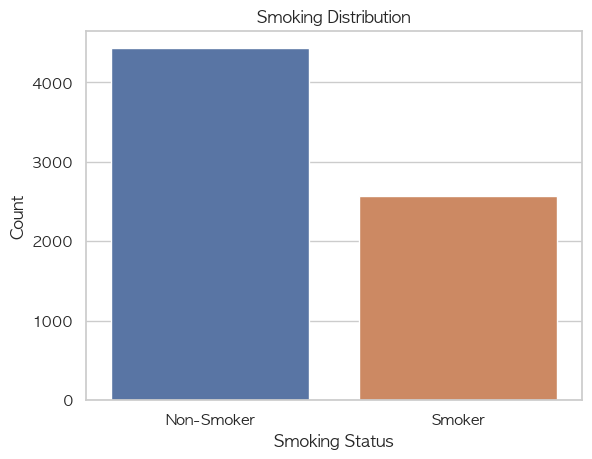

```python
# 데이터프레임이 train이라면 다음과 같이 사용
sns.countplot(x='label', data=train)

plt.title('Smoking Distribution')
plt.xlabel('Smoking Status')
plt.ylabel('Count')
plt.xticks(ticks=[0,1], labels=['Non-Smoker', 'Smoker'])
plt.show()
```

### 전체 데이터 분포 확인

위에서 확인한 smoking(target) 변수를 제외하고 각 피처의 분포를 확인하겠습니다.

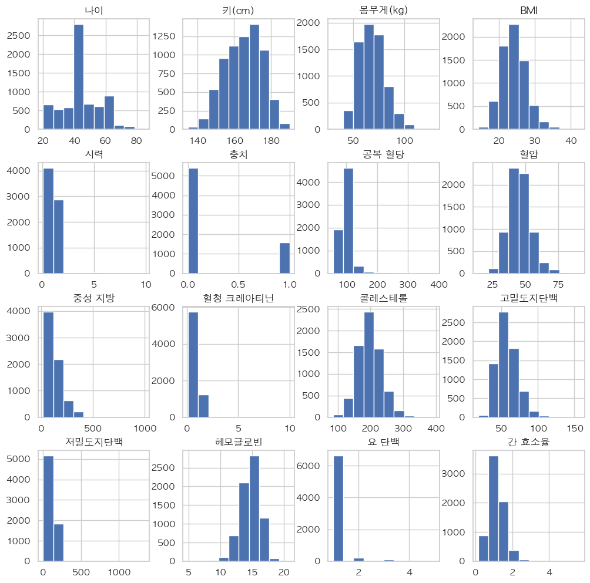

```python
except_target = train.drop('label', axis = 1)
except_target.hist(figsize = (12,12))
plt.show()
```

### 연령별 흡연율 확인

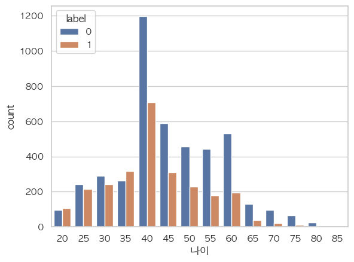

```python
sns.countplot(x = '나이', hue = 'label', data = train)
plt.show()
```

## 상관관계 확인

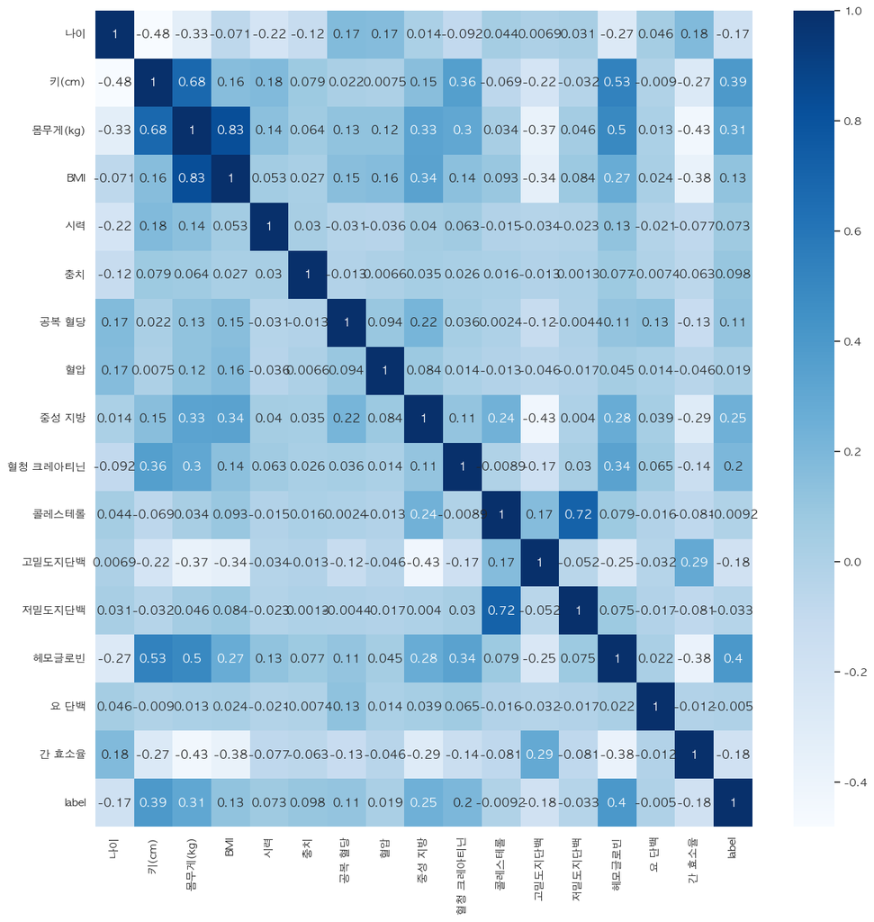

```python
plt.figure(figsize = (15,15), dpi = 100)
sns.heatmap(train.corr(), annot = True, cmap = 'Blues')
plt.show()
```

# 데이터 전처리

## 이상치 처리

시력, 공복 혈당, 중성 지방, 혈청 크레아티닌, 요단백, 간 효소율

```python
train.columns
```

```
Index(['ID', '나이', '키(cm)', '몸무게(kg)', 'BMI', '시력', '충치', '공복 혈당', '혈압',
       '중성 지방', '혈청 크레아티닌', '콜레스테롤', '고밀도지단백', '저밀도지단백', '헤모글로빈', '요 단백',
       '간 효소율', 'label'],
      dtype='object')
```

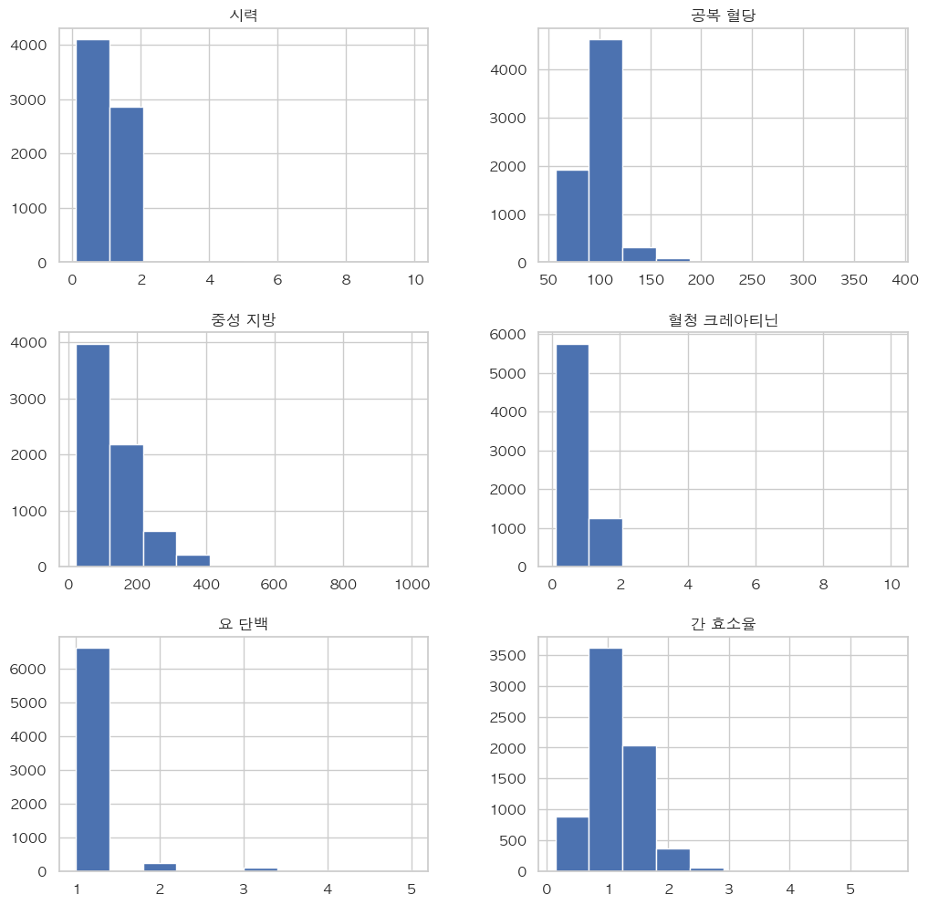

```python
train[['시력', '공복 혈당', '중성 지방', '혈청 크레아티닌', '요 단백', '간 효소율']].hist(figsize=(12,12))
plt.show()
```

```
{'whiskers': [<matplotlib.lines.Line2D at 0x7fb9a1f9a1c0>,
 'caps': [<matplotlib.lines.Line2D at 0x7fb9a1f9a760>,
 'boxes': [<matplotlib.lines.Line2D at 0x7fb9a1f8dfd0>],
 'medians': [<matplotlib.lines.Line2D at 0x7fb9a1f9ad00>],
 'fliers': [<matplotlib.lines.Line2D at 0x7fb9a1f9afd0>],
 'means': []}
```

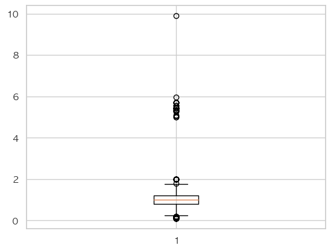

```python
plt.boxplot(train['시력'])
```

```python
###
```

## 로그 변환

- 로그 변환은 산점도를 그려 보고 해야 한다. 그냥 한다고 해서 모델 성능이 무조건 좋아지지는 않는다.
- 해야 하면 train data에만 적용할 것.

```python
###
```

## 구간화

BMI < 18.5: 저체중 18.5 <= BMI < 24.9: 정상체중 25 <= BMI < 29.9: 과체중 30 <= BMI: 비만

```python
# from sklearn.preprocessing import OneHotEncoder

# 학습 데이터로 OneHotEncoder 학습
# encoder = OneHotEncoder()
# encoder.fit(X_train)  # X_train은 학습 데이터의 피쳐들로 이루어진 데이터프레임

# 학습된 인코더를 학습 데이터와 테스트 데이터에 적용
# X_train_encoded = encoder.transform(X_train)
# X_test_encoded = encoder.transform(X_test)  # X_test는 테스트 데이터의 피쳐들로 이루어진 데이터프레임
```

## 컬럼 생성

```python
###
```

## 컬럼 삭제

```python
train.drop(['ID'], axis=1, inplace=True)
test.drop(['ID'], axis=1, inplace=True)
```

```python
train.head(3)
```

|  | 나이 | 키(cm) | 몸무게(kg) | BMI | 시력 | 충치 | 공복 혈당 | 혈압 | 중성 지방 | 혈청 크레아티닌 | 콜레스테롤 | 고밀도지단백 | 저밀도지단백 | 헤모글로빈 | 요 단백 | 간 효소율 | label |
| --- | --- | --- | --- | --- | --- | --- | --- | --- | --- | --- | --- | --- | --- | --- | --- | --- | --- |
| 0 | 35 | 170 | 70 | 24.22 | 1.10 | 1 | 98 | 40 | 80 | 1.3 | 211 | 75 | 120 | 15.9 | 1 | 1.53 | 1 |
| 1 | 40 | 150 | 55 | 24.44 | 1.00 | 0 | 173 | 39 | 104 | 0.6 | 251 | 46 | 184 | 11.8 | 1 | 1.45 | 0 |
| 2 | 60 | 170 | 50 | 17.30 | 0.75 | 0 | 96 | 40 | 61 | 0.8 | 144 | 43 | 89 | 15.3 | 1 | 1.04 | 0 |

## 스케일링 (정규화)

1. 표준화(Standardization):
- 상황: 표준화는 데이터의 분포가 정규 분포를 따르는 것을 가정할 때 주로 사용됩니다.
- 메커니즘: 표준화는 평균을 0, 표준편차를 1로 만들어 데이터를 표준 정규 분포로 변환합니다.
- 사용 사례: 일반적으로 모델들이 평균이 0이고 표준편차가 1인 데이터에 잘 동작하므로, 선형 회귀, 로지스틱 회귀, 신경망 등 다양한 모델에서 사용됩니다. SVM과 같은 일부 모델은 표준화된 데이터를 선호합니다.
1. 정규화(Normalization):
- 상황: 피쳐들의 범위가 다른 상황에서 사용됩니다. 예를 들어 피쳐 간의 단위가 다를 때 사용됩니다.
- 메커니즘: 정규화는 데이터를 최소값과 최대값 사이의 범위로 변환하여 0에서 1 사이의 값을 가지도록 만듭니다.
- 사용 사례: 정규화는 k-최근접 이웃 분류, 신경망에서의 이미지 처리와 같이 피쳐의 스케일이 다를 때 주로 사용됩니다. 최소-최대 정규화는 SVM과 같은 일부 모델에서도 사용될 수 있습니다.

```python
# Normalization
```

```python
# Min-max scaling
```

## PCA

```python
###
```

# 데이터 분할

```python
# 데이터를 학습용과 검증용 나눕니다.
train_data, valid_data = train_test_split(train, test_size=0.2, random_state=42)
```

# 모델 학습

```python
random_seed = 42
```

```python
# AutoGluon을 활용하여 모델 학습
predictor = TabularPredictor(label='label').fit(train_data, presets='best_quality')
```

[output not shown]

[output cut: 67 more lines]

[output not shown]

# 성능 평가

```python
# 검증 데이터로 성능 평가
results = predictor.evaluate(valid_data)
print(results)
```

```
Evaluation: accuracy on test data: 0.7257142857142858
Evaluations on test data:
{
    "accuracy": 0.7257142857142858,
    "balanced_accuracy": 0.7150881415183002,
    "mcc": 0.422768082751542,
    "roc_auc": 0.7991497659221263,
    "f1": 0.6437847866419296,
    "precision": 0.6152482269503546,
    "recall": 0.6750972762645915
}
```

```
{'accuracy': 0.7257142857142858, 'balanced_accuracy': 0.7150881415183002, 'mcc': 0.422768082751542, 'roc_auc': 0.7991497659221263, 'f1': 0.6437847866419296, 'precision': 0.6152482269503546, 'recall': 0.6750972762645915}
```

```python
# 리더보드 확인
leaderboard = predictor.leaderboard(valid_data)
leaderboard
```

```
                     model  score_test  score_val  pred_time_test  pred_time_val   fit_time  pred_time_test_marginal  pred_time_val_marginal  fit_time_marginal  stack_level  can_infer  fit_order
0      WeightedEnsemble_L2    0.725714   0.747679        0.227498       0.585905  14.346524                 0.002507                0.006913           1.103948            2       True          9
1  RandomForestEntr_BAG_L1    0.720714   0.732679        0.067739       0.179828   0.815762                 0.067739                0.179828           0.815762            1       True          4
2          CatBoost_BAG_L1    0.720000   0.744643        0.011952       0.011556  11.214865                 0.011952                0.011556          11.214865            1       True          5
3  RandomForestGini_BAG_L1    0.718571   0.728036        0.070960       0.198037   0.778918                 0.070960                0.198037           0.778918            1       True          3
4    ExtraTreesGini_BAG_L1    0.716429   0.730536        0.074340       0.189571   0.433031                 0.074340                0.189571           0.433031            1       True          6
5    ExtraTreesEntr_BAG_L1    0.714286   0.721607        0.081979       0.189625   0.462652                 0.081979                0.189625           0.462652            1       True          7
6           XGBoost_BAG_L1    0.711429   0.737143        0.093405       0.025645   4.992033                 0.093405                0.025645           4.992033            1       True          8
7    KNeighborsDist_BAG_L1    0.678571   0.674107        0.031866       0.068873   0.007776                 0.031866                0.068873           0.007776            1       True          2
8    KNeighborsUnif_BAG_L1    0.666429   0.663036        0.033424       0.063336   0.011535                 0.033424                0.063336           0.011535            1       True          1
```

|  | model | score_test | score_val | pred_time_test | pred_time_val | fit_time | pred_time_test_marginal | pred_time_val_marginal | fit_time_marginal | stack_level | can_infer | fit_order |
| --- | --- | --- | --- | --- | --- | --- | --- | --- | --- | --- | --- | --- |
| 0 | WeightedEnsemble_L2 | 0.725714 | 0.747679 | 0.227498 | 0.585905 | 14.346524 | 0.002507 | 0.006913 | 1.103948 | 2 | True | 9 |
| 1 | RandomForestEntr_BAG_L1 | 0.720714 | 0.732679 | 0.067739 | 0.179828 | 0.815762 | 0.067739 | 0.179828 | 0.815762 | 1 | True | 4 |
| 2 | CatBoost_BAG_L1 | 0.720000 | 0.744643 | 0.011952 | 0.011556 | 11.214865 | 0.011952 | 0.011556 | 11.214865 | 1 | True | 5 |
| 3 | RandomForestGini_BAG_L1 | 0.718571 | 0.728036 | 0.070960 | 0.198037 | 0.778918 | 0.070960 | 0.198037 | 0.778918 | 1 | True | 3 |
| 4 | ExtraTreesGini_BAG_L1 | 0.716429 | 0.730536 | 0.074340 | 0.189571 | 0.433031 | 0.074340 | 0.189571 | 0.433031 | 1 | True | 6 |
| 5 | ExtraTreesEntr_BAG_L1 | 0.714286 | 0.721607 | 0.081979 | 0.189625 | 0.462652 | 0.081979 | 0.189625 | 0.462652 | 1 | True | 7 |
| 6 | XGBoost_BAG_L1 | 0.711429 | 0.737143 | 0.093405 | 0.025645 | 4.992033 | 0.093405 | 0.025645 | 4.992033 | 1 | True | 8 |
| 7 | KNeighborsDist_BAG_L1 | 0.678571 | 0.674107 | 0.031866 | 0.068873 | 0.007776 | 0.031866 | 0.068873 | 0.007776 | 1 | True | 2 |
| 8 | KNeighborsUnif_BAG_L1 | 0.666429 | 0.663036 | 0.033424 | 0.063336 | 0.011535 | 0.033424 | 0.063336 | 0.011535 | 1 | True | 1 |

```python
# 피쳐 중요도 확인
feature_importance = predictor.feature_importance(valid_data)
print(feature_importance)
```

```
Computing feature importance via permutation shuffling for 16 features using 1400 rows with 5 shuffle sets...
	24.57s	= Expected runtime (4.91s per shuffle set)
	3.83s	= Actual runtime (Completed 5 of 5 shuffle sets)
```

```
          importance    stddev   p_value  n  p99_high   p99_low
헤모글로빈       0.049857  0.005877  0.000023  5  0.061958  0.037756
키(cm)       0.039000  0.007433  0.000151  5  0.054305  0.023695
중성 지방       0.019000  0.006480  0.001399  5  0.032342  0.005658
나이          0.017429  0.003297  0.000147  5  0.024216  0.010641
충치          0.009429  0.004933  0.006456  5  0.019586 -0.000729
고밀도지단백      0.008143  0.007330  0.033955  5  0.023235 -0.006949
저밀도지단백      0.006857  0.003373  0.005226  5  0.013802 -0.000088
시력          0.006000  0.004860  0.025414  5  0.016007 -0.004007
공복 혈당       0.005429  0.004244  0.022958  5  0.014167 -0.003310
혈청 크레아티닌    0.001714  0.002505  0.100357  5  0.006872 -0.003444
BMI         0.001571  0.004386  0.233955  5  0.010602 -0.007459
혈압          0.001571  0.004268  0.228288  5  0.010359 -0.007216
콜레스테롤       0.001286  0.006215  0.333847  5  0.014082 -0.011510
간 효소율       0.001286  0.006877  0.348692  5  0.015446 -0.012875
몸무게(kg)    -0.000286  0.003373  0.570501  5  0.006659 -0.007231
요 단백       -0.000714  0.001429  0.836918  5  0.002227 -0.003656
```

# 예측

```python
# 테스트 데이터로 예측
predictions = predictor.predict(test)

print(predictions)
```

[output not shown]

# 제출 파일 생성

```python
# 제출 파일을 읽어옵니다.
submit = pd.read_csv('data/sample_submission.csv')

# 예측한 값을 TARGET 컬럼에 할당합니다.
submit['label'] = predictions
submit.head()
```

|  | ID | label |
| --- | --- | --- |
| 0 | TEST_0000 | 0 |
| 1 | TEST_0001 | 0 |
| 2 | TEST_0002 | 1 |
| 3 | TEST_0003 | 1 |
| 4 | TEST_0004 | 0 |

```python
# 예측한 결과를 파일로 저장합니다. index 인자의 값을 False로 설정하지 않으면 제출이 정상적으로 진행되지 않습니다.
submit.to_csv('submission/submission_'+datetime.datetime.now().strftime("%Y%m%d%H%M")+'.csv', index = False)
```

끝.